# CGM experiment 2023-01-01

For 2 weeks, I've used Freestyle Libre 2 to continuously monitor my blood clucose and had some extremely interesting learnings.

```python
import pandas as pd
import numpy as np
from plotnine import *
from datetime import datetime, timedelta
from mizani.formatters import date_format

DATE_FORMAT = "%Y-%m-%d"
```

```python
df = pd.read_csv("./LuvsandondovLkhamsuren_glucose_1-19-2023.csv")
df = df.rename(columns={"Historic Glucose mg/dL": "glucose"})
df["ts"] = pd.to_datetime(df["Device Timestamp"])
df["day"] = pd.to_datetime(df["ts"].dt.date)
df["time"] = df["ts"].dt.time
```

```python
def plot_glucose(_df: pd.DataFrame, start: str):

    end_date = datetime.strptime(start, DATE_FORMAT) + timedelta(days=1) + timedelta(hours=6)


    segment_df = _df.query(f"'{start}' <= ts & ts <= '{end_date}'")
    label_df = (
        pd.melt(
            segment_df.query("~food.isnull() | ~drink.isnull() | ~exercise.isnull()", engine = "python"),
            id_vars=["ts", "day", "time", "glucose"],
            value_vars=["food", "drink", "exercise"],
        )
        .query("~value.isnull()", engine = "python")
    )

    avg_df = (
        segment_df
        .query(f"ts <= '{end_date.strftime(DATE_FORMAT)}'")
        .groupby("Device")
        .mean()
        .reset_index()
        .assign(x = lambda _: np.max(segment_df["ts"]))
        .assign(y = lambda _: np.max(segment_df["glucose"]))
    )

    return (
        segment_df
        .pipe(ggplot)
        +aes(x = "ts", y = "glucose")
        +geom_line()
        +geom_point(data = label_df, fill='none')
        +geom_label(
            data = label_df,
            mapping = aes(label = "value", color = "variable"),
            size=8,
            adjust_text={
                'arrowprops': {'arrowstyle': '->'}
            }
        )
        +geom_text(data = avg_df, mapping = aes(x = "x", y = "y", label = "np.round(glucose, 1)"))
        +geom_hline(yintercept = 130, linetype = "dotted")
        +labs(
            title = f"2d glucose for {start}",
            x = "Time"
        )
        +theme(legend_position="none")
        +scale_x_timedelta(
            breaks=lambda x: pd.to_timedelta(
                pd.Series(range(0, 10)),
                unit='h'
            )
        )
    )
```

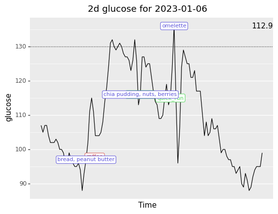

```python
plot_glucose(df, "2023-01-06")
```

Notes:

- Bread with peanut butter does have a small spike, but nothing to be concerned
- Light dinners with low carb (such as omellete, salmon) results in nice drop in glucose overnight

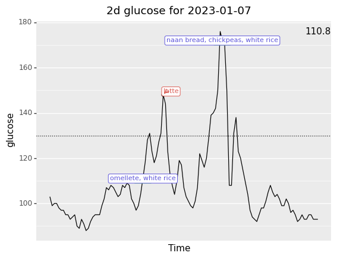

```python
plot_glucose(df, "2023-01-07")
```

Notes:

- Ideally I can combine my food, otherwise latte by itself after lunch spiked me to 150
- Carb heavy food (such as bread, rice) is the only time I have gone over 170 (100 -> 170)
- Heavy spike for dinner disrupted my sleep because my glucose drops sharply & have to rebound during sleep period

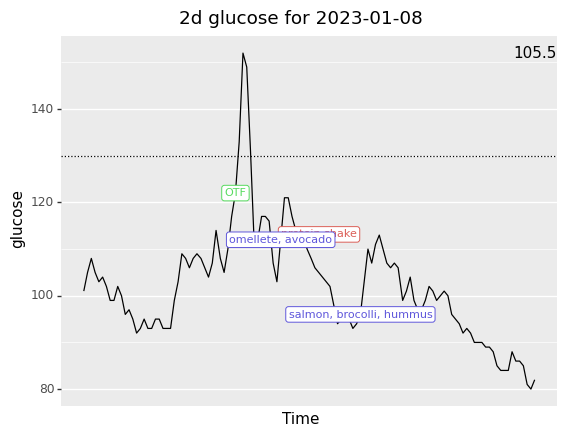

```python
plot_glucose(df, "2023-01-08")
```

Notes:

- Heavy workout sometime can spike BG, but have nice effect of reducing spikes for the rest of the day
- Good dinner is highly suggestive of good sleep & low BG

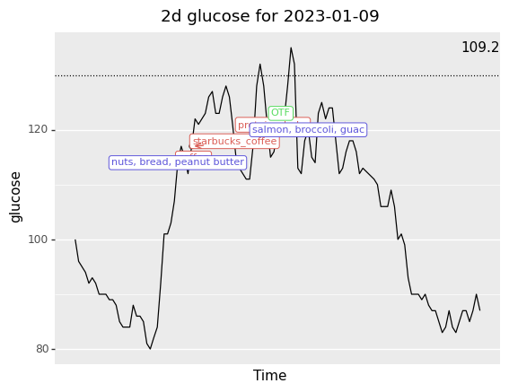

```python
plot_glucose(df, "2023-01-09")
```

Notes

- Starbucks coffee early in the day spiked my BG and it never came down for the rest of the day

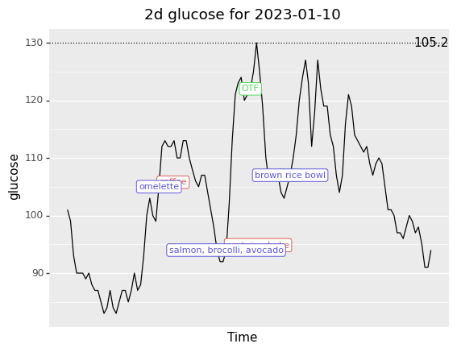

```python
plot_glucose(df, "2023-01-10")
```

Notes:

- Brown rice was only OK after OTF

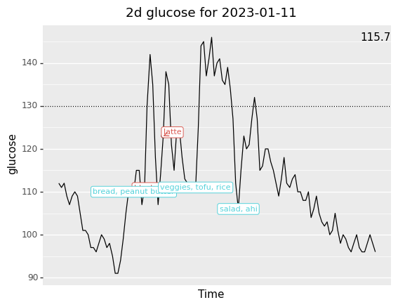

```python
plot_glucose(df, "2023-01-11")
```

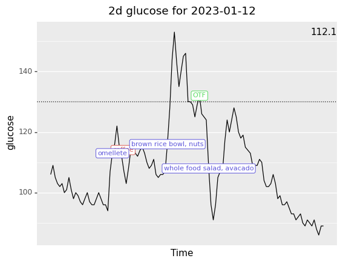

```python
plot_glucose(df, "2023-01-12")
```

- Brown rice bowl before workout had effect of 105 -> 155

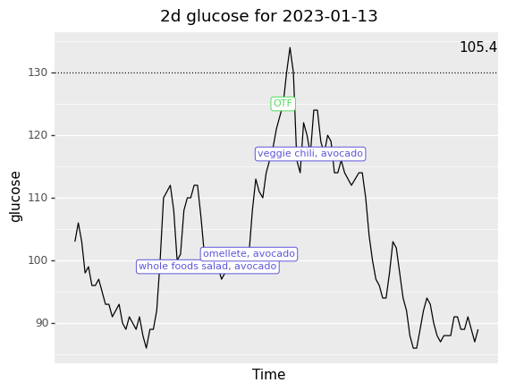

```python
plot_glucose(df, "2023-01-13")
```

- Veggie chili after workout had no spike in BG

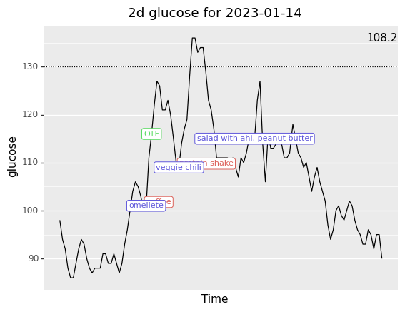

```python
plot_glucose(df, "2023-01-14")
```

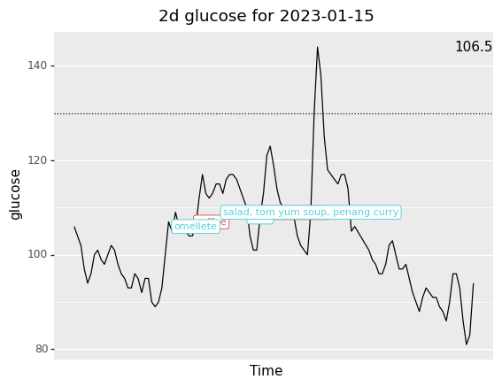

```python
plot_glucose(df, "2023-01-15")
```

- Olay was not that bad if we avoid rice, most likely the spike is due to the sweet salad dressing

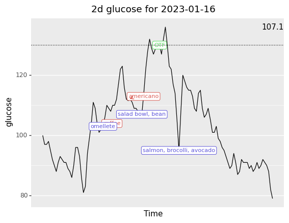

```python
plot_glucose(df, "2023-01-16")
```

- Omellete, salmon brocolli, salad are the best foods so far

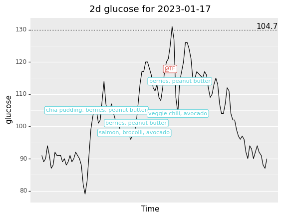

```python
plot_glucose(df, "2023-01-17")
```

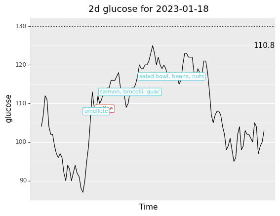

```python
plot_glucose(df, "2023-01-18")
```

### Did I have higher GB on days when I didn't workout?

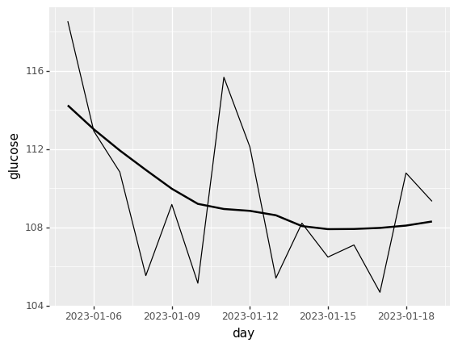

```python
daily_df = (
    df
    .assign(had_otf = lambda r: r["exercise"] == "OTF")
    .groupby("day")
    .mean()
    .reset_index()
    .assign(had_otf = lambda r: r["had_otf"] > 0)
)

(
    daily_df
    .pipe(ggplot)
    +aes(x = "day", y = "glucose")
    +geom_line()
    +geom_smooth()
    +scale_x_date(breaks = "3 day")
)
```

```python
from scipy.stats import ttest_ind

cat1 = daily_df[(daily_df['had_otf'])]
cat2 = daily_df[(~daily_df['had_otf'])]

ttest_ind(cat1['glucose'], cat2['glucose'])
```

```
Ttest_indResult(statistic=-2.8595327029299726, pvalue=0.013409623308817542)
```

```python
df.mean()
```

```
Record Type      0.000000
glucose        108.953077
dtype: float64
```